# Tarea PC2

Jaime Gomez, Enrique Figueroa

24/06/2019

## Identificacion

Se cargan las libs necesarias y se convierten los datos a formato de serie de tiempo.

```r
library(fpp2)
library(tseries)
library(urca)
library(forecast)
```

```r
datos = read.csv("Ingresos_Tributarios.csv",T)
```

```r
(ingtrib = ts(datos[,2], start = c(1994,1), frequency = 4 ) )
```

```
##           Qtr1      Qtr2      Qtr3      Qtr4
## 1994 0.6627500 0.9312080 0.7529020 0.8173090
## 1995 1.1138521 1.0680324 1.0271200 1.0454669
## 1996 1.5207443 1.4187771 2.0859340 1.6057300
## 1997 1.8647680 1.8446810 2.3157750 3.0042065
## 1998 2.6287664 2.4757263 3.0832699 2.5815645
## 1999 1.5068215 1.2385365 1.3204248 1.4199346
## 2000 1.1879299 1.2173540 1.1463425 1.2223606
## 2001 0.7692314 0.7294696 0.8325805 0.7848449
## 2002 0.7826876 0.8904181 0.8859879 1.0133890
## 2003 0.7090339 0.7759149 0.9260493 0.8800331
## 2004 1.5026012 0.5619000 0.5423505 0.5410117
## 2005 0.6941485 0.5581617 0.6509886 0.7170362
## 2006 0.6398369 0.5913774 0.6420558 0.8382395
## 2007 1.1270786 1.1062645 0.9192083 1.0685704
## 2008 1.2336863 0.9666754 1.4132552 1.1881616
## 2009 1.1244193 1.0281722 0.9789397 0.9899104
## 2010 1.0927103 1.2800866 1.9140740 2.4547519
## 2011 2.1757917 1.3602967 1.2949194 2.0588609
## 2012 2.4227322 1.8099130 2.7588545 3.9666795
## 2013 4.4069596 2.9435412 3.9585142 4.1816277
## 2014 3.6923229 3.3013438 2.5534972 3.4883314
## 2015 4.9686005 3.5955212 5.1276123 6.3581836
## 2016 7.4230351 5.3072075 6.0035339 7.2163786
## 2017 9.3659716 4.9587355 7.1589863 8.3632169
## 2018 8.4627786 6.7689438 8.1818438
```

Notamos en las graficas ACF, domina la tendencia. En la grafica de lineas hay una tendencia creciente fuerte de ingresos tributarios en los ultimos años…

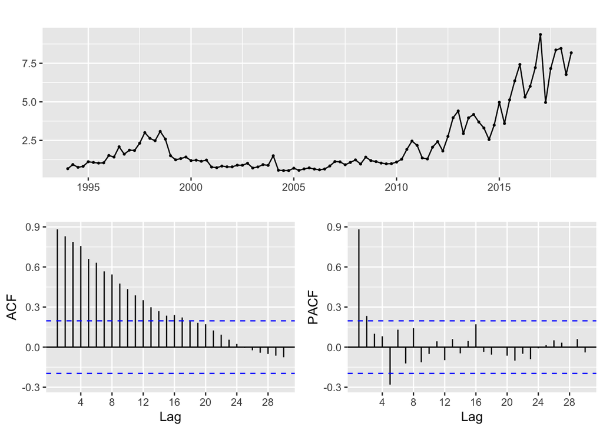

```r
forecast::ggtsdisplay(ingtrib,lag = 30)
```

… especialmente en el primer trimestre del año, donde se aprecia que su mediana supera a los otros trimestres.

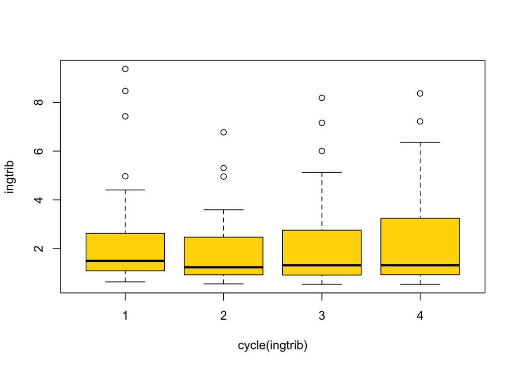

```r
boxplot(ingtrib ~ cycle(ingtrib), col="gold")
```

## Pruebas de estacionariedad

Realizamos pruebas de estacionariedad

```r
kpss.test(euretail)$p.value
```

```
## [1] 0.01
```

```r
adf.test(euretail)$p.value
```

```
## [1] 0.99
```

```r
ur.df(euretail)@teststat
```

```
##                tau1
## statistic 0.9775485
```

```r
pp.test(euretail)$p.value
```

```
## [1] 0.99
```

```r
ur.pp(euretail)@teststat
```

```
## [1] -2.909147
```

Diferenciamos una vez para buscar estacionarizarla.

```r
tseries::kpss.test(diff(ingtrib))$p.value
```

```
## [1] 0.06322233
```

No se rechaza la Ho de estacionariedad de la serie.

```r
tseries::adf.test(diff(ingtrib))$p.value
```

```
## [1] 0.01
```

Se rechaza la Ho de raiz unitaria, de modo que se acepta Ha de estacionariedad de la serie.

```r
urca::ur.df(diff(ingtrib))@teststat
```

```
##               tau1
## statistic -11.2088
```

Estadistico tau, Abs(-11.2088) es mayor que 3, de modo que se acepta Ha de estacionariedad de la serie.

```r
tseries::pp.test(diff(ingtrib))$p.value
```

```
## [1] 0.01
```

El pvalue menor que 0.01 implica aceptar la Ha de estacionariedad de la serie.

```r
urca::ur.pp(diff(ingtrib))@teststat
```

```
## [1] -103.2213
```

El estadistico arroja -103.2213, lo que significa que se acepta la Ha de estacionariedad de la serie.

Con una diferenciacion hemos estacionarizado la serie. Veamos los correlogramas, con una diferenciacion.

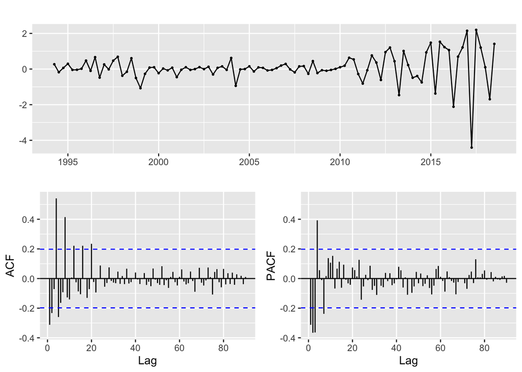

```r
forecast::ggtsdisplay(diff(ingtrib), lag=90)
```

ACF sugiere que las autocorrelaciones se truncan en el segundo desfase, de modo que podemos probar con q=2 o q=1.Entonces p=0.

Por otro lado, la sautocorrelaciones cada cuatro puntos se truncan en dos desfases, de modo que podemos probar con q=2 y q=1.

Es decir, podemos tentar los modelos:

ARIMA(0,1,1)(0,1,1)

ARIMA(0,1,1)(0,1,2)

ARIMA(0,1,2)(0,1,1)

ARIMA(0,1,2)(0,1,2)

Veamos lo que sugiere auto.arima, con una diferenciacion.

```r
forecast::auto.arima(y = ingtrib, d = 1)
```

```
## Series: ingtrib
## ARIMA(0,1,1)(0,1,2)[4]
##
## Coefficients:
##           ma1     sma1    sma2
##       -0.3815  -0.7163  0.1992
## s.e.   0.0962   0.1105  0.1224
##
## sigma^2 estimated as 0.3492:  log likelihood=-83.55
## AIC=175.1   AICc=175.55   BIC=185.27
```

Como se puede observar auto.arima sugiere ARIMA(0,1,1)(0,1,2)

## Modelamiento

```r
mod_1 = Arima(y = ingtrib, order = c(0,1,1), seasonal = c(0,1,1))
summary(mod_1)
```

```
## Series: ingtrib
## ARIMA(0,1,1)(0,1,1)[4]
##
## Coefficients:
##           ma1     sma1
##       -0.3871  -0.6079
## s.e.   0.0997   0.0763
##
## sigma^2 estimated as 0.3565:  log likelihood=-84.91
## AIC=175.81   AICc=176.08   BIC=183.44
##
## Training set error measures:
##                      ME      RMSE       MAE      MPE     MAPE      MASE
## Training set 0.02461882 0.5755547 0.3836955 -1.89037 19.05775 0.5973896
##                      ACF1
## Training set -0.001984757
```

```r
mod_2 = Arima(y = ingtrib, order = c(0,1,1), seasonal = c(0,1,2))
summary(mod_2)
```

```
## Series: ingtrib
## ARIMA(0,1,1)(0,1,2)[4]
##
## Coefficients:
##           ma1     sma1    sma2
##       -0.3815  -0.7163  0.1992
## s.e.   0.0962   0.1105  0.1224
##
## sigma^2 estimated as 0.3492:  log likelihood=-83.55
## AIC=175.1   AICc=175.55   BIC=185.27
##
## Training set error measures:
##                      ME      RMSE       MAE       MPE     MAPE      MASE
## Training set 0.02193353 0.5665833 0.3853664 -1.477808 19.95172 0.5999911
##                      ACF1
## Training set -0.008623321
```

```r
mod_3 = Arima(y = ingtrib, order = c(0,1,2), seasonal = c(0,1,1))
summary(mod_3)
```

```
## Series: ingtrib
## ARIMA(0,1,2)(0,1,1)[4]
##
## Coefficients:
##           ma1      ma2     sma1
##       -0.3832  -0.0161  -0.6088
## s.e.   0.1057   0.1522   0.0765
##
## sigma^2 estimated as 0.3603:  log likelihood=-84.9
## AIC=177.8   AICc=178.25   BIC=187.97
##
## Training set error measures:
##                      ME      RMSE       MAE       MPE     MAPE     MASE
## Training set 0.02505507 0.5754568 0.3830875 -1.892348 19.00766 0.596443
##                      ACF1
## Training set -0.005533708
```

```r
mod_4 = Arima(y = ingtrib, order = c(0,1,2), seasonal = c(0,1,2))
summary(mod_4)
```

```
## Series: ingtrib
## ARIMA(0,1,2)(0,1,2)[4]
##
## Coefficients:
##           ma1     ma2     sma1    sma2
##       -0.3877  0.0171  -0.7160  0.2006
## s.e.   0.1099  0.1444   0.1108  0.1226
##
## sigma^2 estimated as 0.3531:  log likelihood=-83.54
## AIC=177.09   AICc=177.77   BIC=189.8
##
## Training set error measures:
##                      ME      RMSE       MAE       MPE   MAPE      MASE
## Training set 0.02155895 0.5665818 0.3864322 -1.479893 20.028 0.6016505
##                      ACF1
## Training set -0.003637496
```

## Diagnostico

Una vez que tenemos varios modelos tentativos, realizamos pruebas de diagnostico.

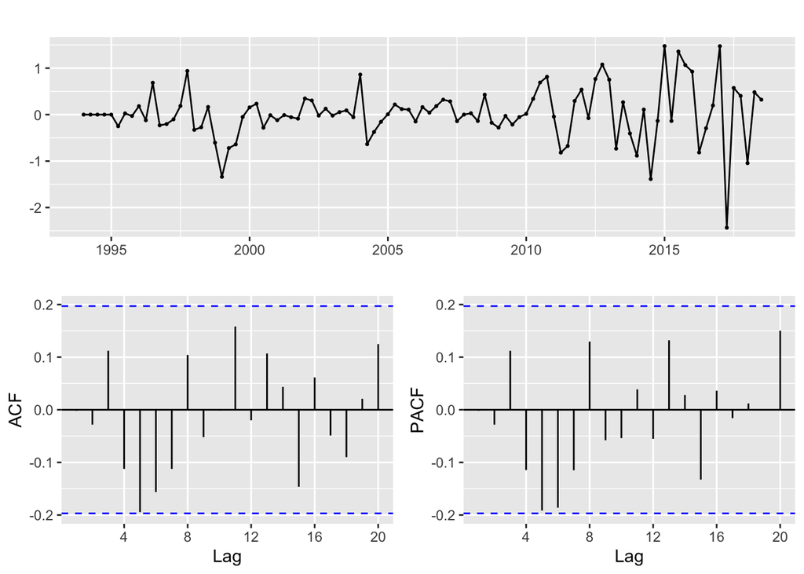

```r
res1 = residuals(mod_1)
res2 = residuals(mod_2)
res3 = residuals(mod_3)
res4 = residuals(mod_4)

ggtsdisplay(res1)
```

El modelo 1 muestra un buen comportamiento de residuales: no hay autocorrelaciones fuera de las bandas.

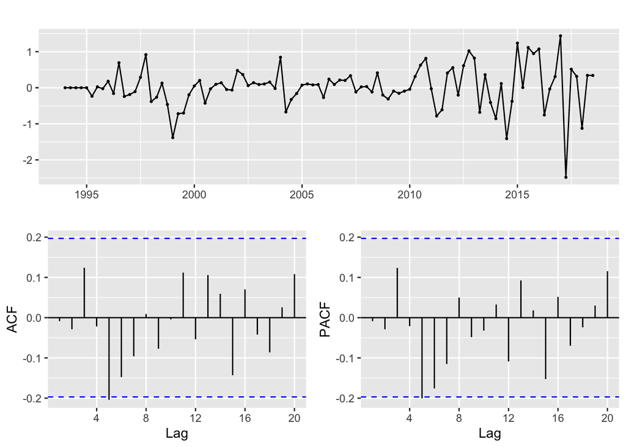

```r
ggtsdisplay(res2)
```

El modelo 2 tambien tiene un aceptable comportamiento de residuales, pues salvo una de las autocorrelaciones, todas estan dentro de las bandas.

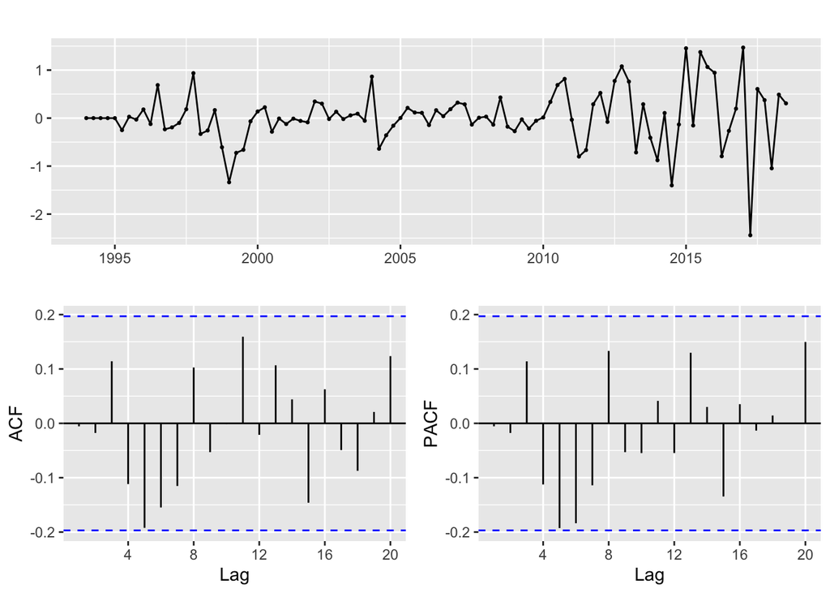

```r
ggtsdisplay(res3)
```

El modelo 3 tambien exhibe un buen comportamiento de residuales: no hay autocorrelaciones fuera de las bandas.

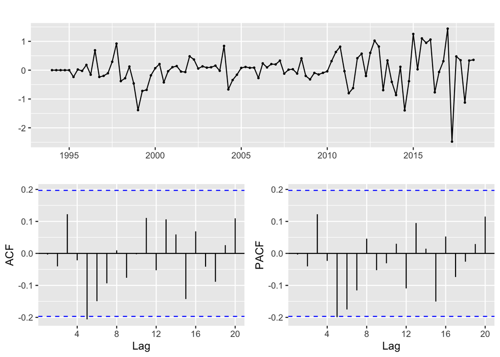

```r
ggtsdisplay(res4)
```

```r
t.test(res1)$p.value
```

```
## [1] 0.6726189
```

```r
t.test(res2)$p.value
```

```
## [1] 0.702168
```

```r
t.test(res3)$p.value
```

```
## [1] 0.6671051
```

```r
t.test(res4)$p.value
```

```
## [1] 0.70702
```

Todas los residuales dan resultados satisfactorios respecto a que la media de los residuales de los modelos son significativamente cero, toda vez que los pvalues no rechazan la Ho de media = 0.

```r
shapiro.test(res1)$p.value
```

```
## [1] 5.652081e-05
```

```r
shapiro.test(res2)$p.value
```

```
## [1] 9.012094e-05
```

```r
shapiro.test(res3)$p.value
```

```
## [1] 4.592179e-05
```

```r
shapiro.test(res4)$p.value
```

```
## [1] 0.0001039195
```

El test de normalidad de residuales, sin embargo, muestra que ninguno de los modelos prueba estadisticamente al 10% de significancia que los residuales siguen una distribucion normal. Todavia deben hacerse esfuerzos para mejorar los ajustes de los modelos, por ejemplo, incorporando media o drift, para superar este escollo, toda vez que los pronosticos que se hagan con ellos no seran del todo confiables.

Por otro lado, procedemos a emitir indicadores de exactitud de pronosticos:

```r
accuracy(forecast(mod_1))
```

```
##                      ME      RMSE       MAE      MPE     MAPE      MASE
## Training set 0.02461882 0.5755547 0.3836955 -1.89037 19.05775 0.5973896
##                      ACF1
## Training set -0.001984757
```

```r
accuracy(forecast(mod_2))
```

```
##                      ME      RMSE       MAE       MPE     MAPE      MASE
## Training set 0.02193353 0.5665833 0.3853664 -1.477808 19.95172 0.5999911
##                      ACF1
## Training set -0.008623321
```

```r
accuracy(forecast(mod_3))
```

```
##                      ME      RMSE       MAE       MPE     MAPE     MASE
## Training set 0.02505507 0.5754568 0.3830875 -1.892348 19.00766 0.596443
##                      ACF1
## Training set -0.005533708
```

```r
accuracy(forecast(mod_4))
```

```
##                      ME      RMSE       MAE       MPE   MAPE      MASE
## Training set 0.02155895 0.5665818 0.3864322 -1.479893 20.028 0.6016505
##                      ACF1
## Training set -0.003637496
```

Segun lo anterior, el modelo 3 logra mejor performance en 3 medidas de exactitud (MAE, MAPE y MASE).

## Cross Validation

Realizamos una prueb de cross validacion para probar los modelos con datos distintos de los que sirvieron para construir los modelos.

```r
n    = length(euretail)  # longitud de la serie
k    = 28                # longitud m?nima de la data de entrenamiento (k<n)
ho   = 4                 # longitud de la data de prueba (ho<k<n)
mse1 = mse2 = mse3 = mse4 =  matrix(NA,n-k-ho,ho)
st   = tsp(euretail)[1]  # inicio de la serie

for(i in 1:(n-k-ho)){
  train   = window(ingtrib,
                   end   = st + k/4 + (i-2)/4)
  test    = window(ingtrib,
                   start = st + k/4 + (i-1)/4,
                   end   = st + k/4 + (i-1)/4 + (ho-1)/4)

  modelo1 = Arima(train, order = c(0,1,1), seasonal = c(0,1,1))
  predi1  = forecast(modelo1,h = ho)
  mse1[i,1:length(test)] = (ts(predi1$mean)-ts(test))^2

  modelo2 = Arima(train, order = c(0,1,1), seasonal = c(0,1,2))
  predi2  = forecast(modelo2,h = ho)
  mse2[i,1:length(test)] = (ts(predi2$mean)-ts(test))^2

  modelo3 = Arima(train, order = c(0,1,2), seasonal = c(0,1,1))
  predi3  = forecast(modelo3,h = ho)
  mse3[i,1:length(test)] = (ts(predi3$mean)-ts(test))^2

  modelo4 = Arima(train, order = c(0,1,2), seasonal = c(0,1,2))
  predi4  = forecast(modelo4,h = ho)
  mse4[i,1:length(test)] = (ts(predi4$mean)-ts(test))^2

  }
```

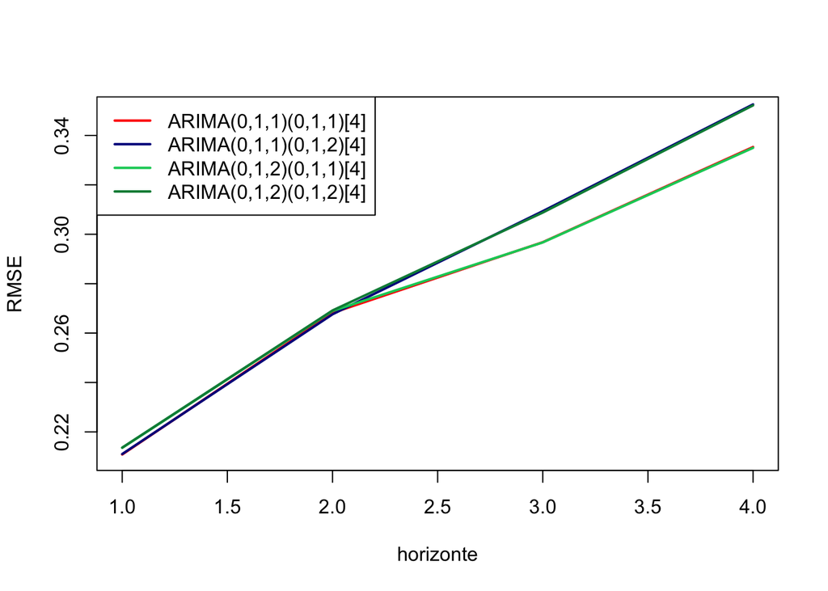

```r
plot(1:ho,
     colMeans(sqrt(mse1),na.rm=TRUE),
     type = "l",
     lwd  = 2,
     col  = "red",
     xlab = "horizonte",
     ylab = "RMSE",
     ylim = c(0.21,0.35))
lines(1:ho,
      colMeans(sqrt(mse2),na.rm=TRUE),
      type = "l",
      lwd  = 2,
      col  = "darkblue")
lines(1:ho,
      colMeans(sqrt(mse3),na.rm=TRUE),
      type = "l",
      lwd  = 2,
      col  = "springgreen3")
lines(1:ho,
      colMeans(sqrt(mse4),na.rm=TRUE),
      type = "l",
      lwd  = 2,
      col  = "springgreen4")
legend("topleft",
       legend = c("ARIMA(0,1,1)(0,1,1)[4]","ARIMA(0,1,1)(0,1,2)[4]","ARIMA(0,1,2)(0,1,1)[4]","ARIMA(0,1,2)(0,1,2)[4]"),
       col    = c("red","darkblue","springgreen3","springgreen4"),
       lty    = 1,
       lwd    = 2)
```

La grafica de la prueba de cross validation no permite dar un veredicto concluyente, como se puede apreciar en el grafifo de arriba.

## Prediccion

Basandonos en que el modelo 3 obtuvo mejores resultados con 3 indicadores de exactitud, realizamos una prediccion con dicho moledol, aun teniendo en cuuenta que la no normalidad de residuales no permite realizar predicciones confiables estadisticamente.

```r
forecast(mod_3, h = 4)
```

```
##         Point Forecast    Lo 80     Hi 80    Lo 95     Hi 95
## 2018 Q4       9.150316 8.381105  9.919528 7.973909 10.326724
## 2019 Q1       9.974806 9.071055 10.878558 8.592638 11.356975
## 2019 Q2       7.743278 6.728273  8.758283 6.190962  9.295594
## 2019 Q3       9.072890 7.957676 10.188105 7.367317 10.778464
```

Graficamente:

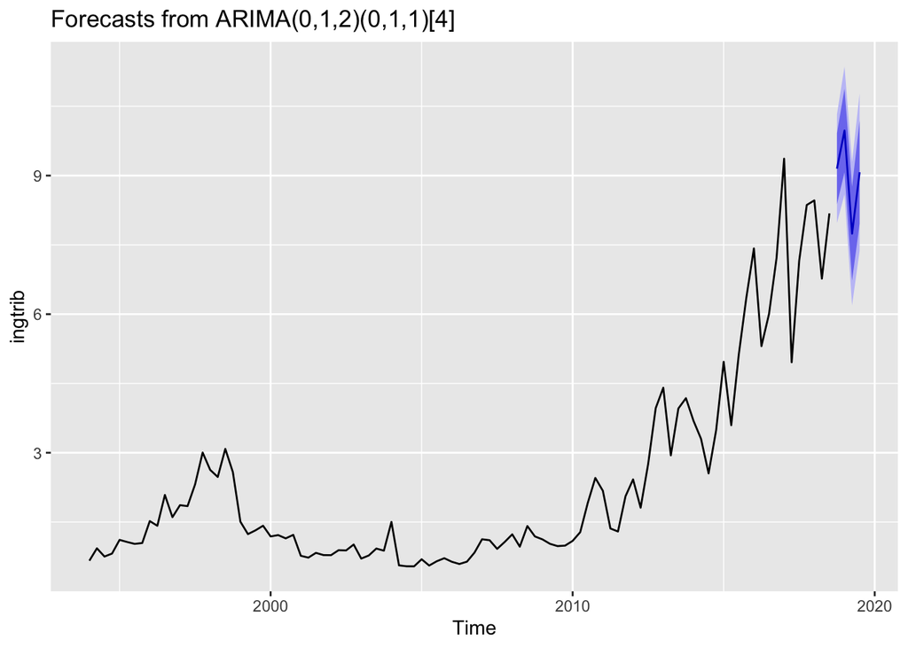

```r
autoplot(forecast(mod_3, h = 4))
```